# Het rendement op alles — door een Belgische bril

150 jaar reële rendementen op aandelen, vastgoed, obligaties en cash (Jordà-Schularick-Taylor), en wat ze betekenen voor een Belgische belegger

Auteur

Robbe De Win

Publicatiedatum

18 mei 2026

[figure not shown]

Persoonlijk financieel plan

18 mei 2026

Voor

# Het rendement op alles — door een Belgische bril

150 jaar reële rendementen op aandelen, vastgoed, obligaties en cash (Jordà-Schularick-Taylor), en wat ze betekenen voor een Belgische belegger

concept

# Inleiding: rendement op alles

Wie vandaag een financieel plan opstelt, leunt — bewust of onbewust — op één getal: het verwachte reële rendement van een gespreide portefeuille. Dat getal bepaalt of een pensioen haalbaar is, of een huis kopen “loont”, en hoeveel een spaarder elke maand opzij moet zetten. Het is dus verbazend hoe zelden de herkomst van dat getal expliciet wordt gemaakt.

Dit rapport repliceert de meest gezaghebbende moderne bron over langetermijnrendementen — Jordà, Knoll, Kuvshinov, Schularick & Taylor (2019), *The Rate of Return on Everything, 1870–2015* — en bekijkt de resultaten door een Belgische bril. De ambitie is drieledig:

1. **Repliceren.** De reële rendementen op aandelen, vastgoed, obligaties en kortlopend schatkistpapier (“bills”) over zestien geavanceerde economieën, 1870–2015, uit de officiële JST Macrohistory-dataset.
2. **België uitdiepen.** Een apart hoofdstuk over de Belgische cijfers, met de ontleding van het vastgoedrendement in huuropbrengst versus prijsstijging, en een kruiscontrole tegen de Damodaran- en Shiller-reeksen uit `market_data`.
3. **Vooruitkijken.** Een appendix die uit dit historische record een onderbouwde set *capital-market assumptions* afleidt en een concreet voorstel formuleert voor de `DMS_BASELINE` die alle cliëntprojecties voedt.

# Data en methodologie

## De JST Macrohistory-dataset

De brondata is de **JST Macrohistory Database** (release R6), het officiële vervolg op de QJE-publicatie van 2019. Het bestand bevat per land en per jaar de nominale *total returns* op vier activaklassen — aandelen (`eq_tr`), woningvastgoed (`housing_tr`), langlopende overheidsobligaties (`bond_tr`) en kortlopend schatkistpapier (`bill_rate`) — naast de consumptieprijsindex (`cpi`) en de ontledingscomponenten (kapitaalwinst en huur-/dividendrendement).

Tabel 1: Dekking van de gerepliceerde JST-dataset

|  | landen | van | tot | observaties |
| --- | --- | --- | --- | --- |
| Aandelen | 16 | 1871 | 2020 | 2258 |
| Vastgoed | 16 | 1871 | 2020 | 1909 |
| Obligaties | 16 | 1871 | 2020 | 2286 |
| Bills | 16 | 1871 | 2020 | 2338 |

De dataset wordt door `src/fetch_jst.py` eenmalig van macrohistory.net gehaald en *vendored* in `data/raw/` (zie `data/raw/INVENTORY.md`). Een Quarto-render draait dus volledig offline. De macrohistory.net-link heet `.xlsx` maar levert een Stata-`.dta`; de fetcher detecteert dit via de magische bytes van het bestand.

## Van nominaal naar reëel

JST rapporteren nominale rendementen. Wij defleren met de **eigen consumptieprijsindex van elk land**:

$$r_{\text{reëel}} = \frac{1 + r_{\text{nominaal}}}{1 + \pi} - 1,$$

waarbij $\pi$ de gerealiseerde jaarinflatie van dat land is. Reële, niet nominale rendementen zijn de juiste basis voor een financieel plan: een spaarder geeft euro’s van morgen uit, niet die van vandaag.

## Bronnen die we niet dupliceren

De Belgische CPI (1920+), de Statbel-woningprijsindex en de ECB-hypotheekrente worden **niet** opnieuw afgeleid: ze worden ingelezen uit het zusterproject `rent_vs_buy_be` (`parsers.load_belgium_cpi/hpi/ecb_mortgage_rate`). De Amerikaanse Damodaran- en Shiller-reeksen komen uit de lokale `market_data`-store via `import market_data as md` — nooit via ruwe yfinance.

# Wereldwijde langetermijnrendementen

## Het kop-cijfer

Tabel 2: Gerepliceerd gelijkgewogen 16-landengemiddelde (reëel, 1870–2015) versus JST-publicatie

|  | Activaklasse | Gerepliceerd | JST gepubliceerd |
| --- | --- | --- | --- |
| 0 | Aandelen | 6.9% | 6.9% |
| 1 | Vastgoed | 6.9% | 7.1% |
| 2 | Obligaties | 2.3% | 2.5% |
| 3 | Bills | 1.0% | 0.9% |

De twee centrale feiten van *The Rate of Return on Everything* komen er helder uit: **vastgoed en aandelen leveren op de zeer lange termijn een vergelijkbaar reëel rendement** (in onze replicatie zelfs nek-aan-nek), en **beide verslaan obligaties en cash met een ruime marge**. De kleine afwijkingen tegenover de gepubliceerde cijfers zijn verwacht: de R6-release loopt door tot 2020 en bevat bronherzieningen ten opzichte van de exacte QJE-druk van 2019.

## Per land en per activaklasse

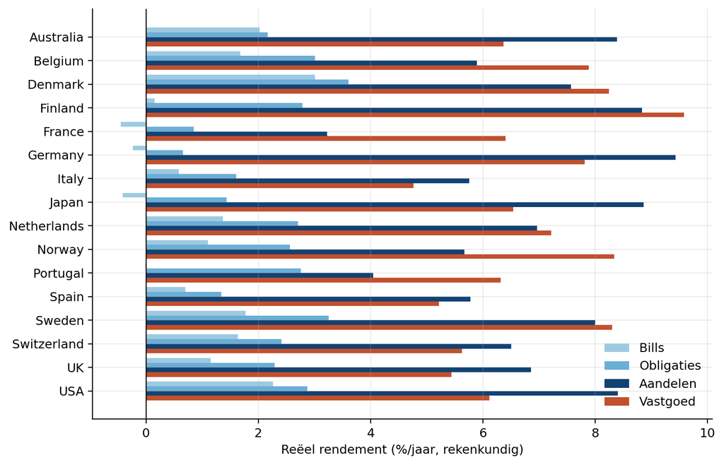

Figuur 1: Reëel rendement per land en activaklasse (rekenkundig gemiddelde, 1870–2015)

De spreiding tússen landen is groot — groter dan beleggers doorgaans aannemen. Aandelenrendementen lopen uiteen van zwaar door oorlog en inflatie geteisterde markten tot de Angelsaksische uitschieters. Vastgoed is opvallend stabieler over landen heen: nergens in het panel was woningvastgoed op de lange termijn een slechte reële belegging. Het is precies die landenspreiding die motiveert waarom een financieel plan niet op één nationaal cijfer mag steunen — het onderwerp van het volgende hoofdstuk.

# België onder de loep

## De Belgische cijfers

Tabel 3: België — reëel rendement per activaklasse (1870–2015)

|  | Activaklasse | Rekenkundig | Meetkundig | Volatiliteit | JST-doel |
| --- | --- | --- | --- | --- | --- |
| 0 | Aandelen | 5.9% | 3.6% | 22.0% | 6.2% |
| 1 | Vastgoed | 7.9% | 6.8% | 15.5% | 7.9% |
| 2 | Obligaties | 3.0% | 2.4% | 10.7% | 3.0% |
| 3 | Bills | 1.7% | 1.2% | 9.9% | 0.9% |

Merk op hoe groot de **volatility drag** is bij aandelen: het meetkundige gemiddelde ligt fors onder het rekenkundige. Bij vastgoed, met zijn veel lagere volatiliteit, is dat gat klein — een tweede reden waarom vastgoed historisch zo aantrekkelijk oogt.

## Vastgoed: huur, geen prijsstijging

Het hardnekkigste misverstand over vastgoed is dat het rendement uit *prijsstijging* komt. JST laten het tegendeel zien. We ontleden het Belgische reële vastgoedrendement in netto huuropbrengst en reële kapitaalwinst:

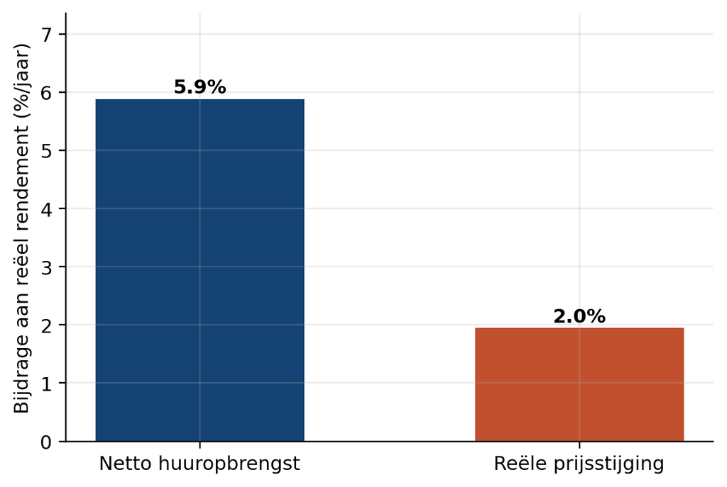

Figuur 2: België — bron van het reële vastgoedrendement: huuropbrengst versus prijsstijging

De boodschap is ondubbelzinnig: het leeuwendeel van het Belgische vastgoedrendement is **huurinkomen**, niet prijsstijging. De reële prijs van Belgisch vastgoed is over 1870–2015 maar bescheiden gestegen. Dat heeft een directe planningsimplicatie: het rendement van een eigen woning die *niet verhuurd* wordt, is grotendeels impliciet (uitgespaarde huur), en een verhuurpand zonder huurinkomsten meerekenen overschat het rendement zwaar.

## Kruiscontrole tegen Damodaran en Shiller

`market_data` bevat geen lange Belgische aandelenreeks; de VS dient als lange-historiek-ijkpunt. De getallen sluiten onderling goed aan:

Tabel 4: Reëel aandelenrendement — JST versus Damodaran/Shiller

|  | Bron | Rekenkundig | Meetkundig | Volatiliteit |
| --- | --- | --- | --- | --- |
| 0 | JST Belgium equity (1870-2015) | 5.9% | 3.6% | 22.0% |
| 1 | JST USA equity (1870-2015) | 8.4% | 6.7% | 18.5% |
| 2 | Damodaran S&P500 real (1928-2025) | 8.6% | 6.8% | 19.3% |
| 3 | Shiller real TR (1871-2026, annualised) | 7.9% | 6.9% | 14.1% |

Belgische aandelen liggen duidelijk *onder* het Amerikaanse en het brede-marktcijfer. De Amerikaanse JST-, Damodaran- en Shiller-reeksen liggen onderling binnen een procentpunt — een geruststellende consistentiecontrole op de methodologie. De les voor het plan: kalibreer op het brede, internationaal gespreide record, niet op de Belgische uitschieter naar beneden.

# Conclusie

Drie conclusies dragen door naar de praktijk van het financieel plan.

**1. Aandelen en vastgoed zijn op de zeer lange termijn elkaars gelijke — maar om verschillende redenen.** Aandelen leveren hun rendement met hoge volatiliteit en dus een forse volatility drag; vastgoed levert een vergelijkbaar reëel rendement met veel minder schommeling, maar dat rendement is grotendeels *huurinkomen*, niet prijsstijging. Een plan dat vastgoedrendement gelijkstelt aan prijsstijging, of dat het impliciete huurvoordeel van een eigen woning negeert, rekent zichzelf arm of rijk.

**2. Eén nationaal-historisch cijfer is een valstrik.** België toont het scherpst: zwakke aandelen, sterk vastgoed. Wie het Belgische aandelenverleden naïef extrapoleert, onderschat een gespreide portefeuille structureel. De juiste kalibratie is het brede, internationaal gespreide record — precies wat de appendix doet.

**3. Het verleden is een bovengrens, geen voorspelling.** De gepubliceerde JST-rendementen zijn rekenkundige gemiddelden over een eeuw met uitzonderlijk gunstige waarderingsexpansie. Voorwaartse *capital-market assumptions* horen daaronder te liggen; de appendix past daarom een expliciete, gedocumenteerde *haircut* toe.

## Kanttekeningen

- **Survivorship en oorlogsbreuken.** Markten die volledig werden weggevaagd (bv. tsaristisch Rusland) ontbreken; het panel is een *overlevenden*-steekproef en overschat daardoor licht.
- **De huurbenchmark voor vastgoed is gevoelig.** JST waarschuwen er zelf voor (Sectie III.C): het vastgoedtotaalrendement reageert sterk op de gekozen huur-prijsverhouding. Het Belgische ~7,9 %-cijfer is robuust binnen een band, niet tot op de komma.
- **R6 ≠ de QJE-druk van 2019.** De gebruikte release loopt door tot 2020 en bevat bronherzieningen; alle cijfers worden daarom tegen een tolerantieband geverifieerd, niet op exacte gelijkheid.
- **Geen lange Belgische aandelenreeks in `market_data`.** De kruiscontrole steunt op Amerikaanse lange reeksen plus de Belgische Statbel/ECB-data uit `rent_vs_buy_be`; het Belgische aandelencijfer komt uitsluitend uit JST.

# Appendix: vooruitkijkende kapitaalmarktveronderstellingen

Alle cliëntprojecties (`shared/projections/`) steunen op één object, `DMS_BASELINE` in `shared/projections/assumptions.py`. Tot nu toe waren die getallen met de hand gezet, zonder herleidbare afleiding. Deze appendix geeft ze een controleerbare oorsprong.

## Afleiding

De methode (geïmplementeerd in `model.derive_cma`):

1. **Verankering op het brede record.** De verwachte *gemiddelden* komen uit het gelijkgewogen 16-landengemiddelde van de reële aandelen- en obligatierendementen over 1870–2015 — een internationaal gespreide belegger, niet een Belgisch-alleen belegger (Belgische aandelen zijn een bekende uitschieter naar beneden).
2. **Voorwaartse haircut.** Op het historische aandelengemiddelde gaat een expliciete haircut van `EQUITY_FORWARD_HAIRCUT` af, omdat de huidige waarderingen (hoge CAPE) ver boven het 1870–2015-gemiddelde liggen en toekomstige rendementen daardoor lager horen te liggen.
3. **Volatiliteit, correlatie en inflatie blijven uit `DMS_BASELINE`.** Het gepoolde cross-country jaarrendement diversifieert het grootste deel van de variantie weg; zijn sigma/correlatie onderschatten wat één reële belegger draagt. Alleen de gemiddelden zijn robuust tegen poolen — de conservatieve, verdedigbare keuze.

Tabel 5: Voorgestelde versus huidige kapitaalmarktveronderstellingen (reëel, jaarbasis)

|  | Parameter | Huidig (DMS_BASELINE) | Voorgesteld |
| --- | --- | --- | --- |
| 0 | Reëel aandelenrendement (μ) | 0.0500 | 0.0549 |
| 1 | Aandelenvolatiliteit (σ) | 0.1700 | 0.1700 |
| 2 | Reëel obligatierendement (μ) | 0.0170 | 0.0236 |
| 3 | Obligatievolatiliteit (σ) | 0.0700 | 0.0700 |
| 4 | Correlatie aandelen/obligaties | 0.1000 | 0.1000 |
| 5 | Inflatie (μ) | 0.0200 | 0.0200 |
| 6 | Inflatievolatiliteit (σ) | 0.0150 | 0.0150 |

De voorgestelde reële aandelenverwachting ligt na de haircut iets boven de huidige 5,0 %: het gepoolde historische gemiddelde is hoog, maar de haircut trekt het richting een verdedigbaar voorwaarts niveau. Obligaties komen historisch wat hoger uit dan de huidige conservatieve 1,7 %.

## Manuele integratiestap

Dit is **bewust geen automatische write-back.** `assumptions.py` is gedeelde cliënt-infrastructuur; een stille programmatorische wijziging zou onreviewbaar zijn en de single-source-of-truth-discipline breken. Wie het voorstel aanvaardt, vervangt het `DMS_BASELINE`-blok in `shared/projections/assumptions.py` met de hand door onderstaand blok:

```
DMS_BASELINE = CapitalMarketAssumptions(
    equity_real_mu=0.0549,
    equity_real_sigma=0.17,
    bond_real_mu=0.0236,
    bond_real_sigma=0.07,
    equity_bond_corr=0.1,
    inflation_mu=0.02,
    inflation_sigma=0.015,
)
```

Daarna herrekenen alle cliëntprojecties automatisch op de nieuwe verankering, en kan dit rapport opnieuw worden gerenderd om de afleiding te herzien. Tot die manuele stap gezet is, blijft `DMS_BASELINE` ongewijzigd en dient `parameters.DMS_BASELINE_DOC` louter als documentatiekopie.